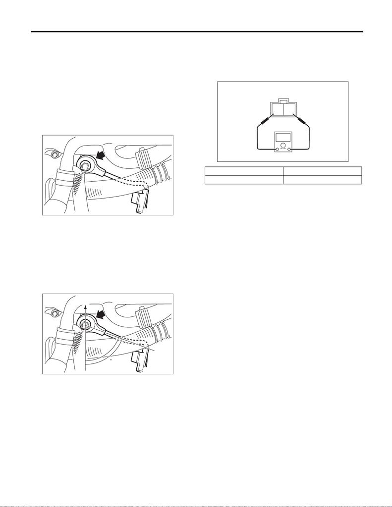

FU(STI)-38

Knock Sensor

FUEL INJECTION (FUEL SYSTEMS)

7. Knock Sensor

A: REMOVAL

1) Disconnect the ground cable from battery.

2) Remove the intercooler. <Ref. to IN(STI)-13,

REMOVAL, Intercooler.>

3) Remove the intake manifold. <Ref. to FU(STI)-

17, REMOVAL, Intake Manifold.>

4) Remove the secondary air combination valve

RH. <Ref. to EC(STI)-54, REMOVAL, Secondary

Air Combination Valve.>

5) Remove the knock sensor from cylinder block.

B: INSTALLATION

1) Install the knock sensor to the cylinder block.

NOTE:

The portion of the knock sensor cord that is pulled

out must be positioned at a 60° angle relative to the

engine rear.

Tightening torque:

24 N·m (2.4 kgf-m, 17.7 ft-lb)

2) Install the secondary air combination valve RH.

<Ref. to EC(STI)-55, SECONDARY AIR COMBI-

NATION VALVE RH, INSTALLATION, Secondary

Air Combination Valve.>

3) Install the intake manifold. <Ref. to FU(STI)-21,

INSTALLATION, Intake Manifold.>

4) Install the intercooler. <Ref. to IN(STI)-14, IN-

STALLATION, Intercooler.>

5) Connect the battery ground terminal.

C: INSPECTION

1) Check that the knock sensor has no deforma-

tion, cracks or other damages.

2) Measure the resistance between knock sensor

terminals.

(A) Front side of vehicle

FU-04494

FU-05758

60

(A)

Terminal No. Standard

1 and 2 560±28 kΩ

2

1

EC-02428